# Pre-Interview exercise CGPS

Rutuja

2/18/2022

Background: QUAST stands for QUality ASsessment Tool. The tool evaluates genome assemblies by computing various metrics.  
data: Quality metrics for bacterial genome sequencing

```r
setwd("C:/Users/Rutuja Chhajed/OneDrive - Nexus365/CGPS/CGPS-rutuja")
data <- read_csv("data.csv", trim_ws = FALSE)
```

Question 1: How many samples that have failed the contamination check (confindr.contam_status.check_result) and have contamination of > 5%  
(confindr.percentage_contamination.metric_value)

Answer: 57 out of 1000 samples have failed the contamination check and have >5% contamination.  
-Samples with 0% contamination % pass, and those >0 failed (67)

```r
table(data$confindr.contam_status.check_result)
```

```
##
## FAILURE    PASS
##      67     933
```

```r
d1<-subset(data, data$confindr.contam_status.check_result=="FAILURE"&data$confindr.percentage_contamination.metric_value>5)
length(unique(d1$sample_name))## samples that failed the contamination check and have >5% contamination.
```

```
## [1] 57
```

```r
#Plotting to see the distribution of contamination percentages in passed and failed samples
#library(ggplot2)
#ggplot(data, aes(x=factor(confindr.contam_status.check_result),y=confindr.percentage_contamination.metric_value)) +
  #geom_boxplot()

#fail<-subset(data,data$confindr.contam_status.check_result=="FAILURE")
#hist(fail$confindr.percentage_contamination.metric_value)#Histogram to better see distribution of contamination percentages
rm(fail)#removing dataframe
rm(d1)#removing dataframe
```

```r
d2<-subset(data, data$`quast.# contigs (>= 1000 bp).metric_value` >=50 & data$quast.N50.metric_value>=750000)
rm(d2)
```

Question 3: Select all numeric columns and rename to remove the .quast prefix and .metric_value suffix  
Rename confindr.percentage_contamination to contamination_percent

```r
library(stringr)
library(dplyr)

nums <- unlist(lapply(data, is.numeric))  #Selecting numeric variables

colnames(data)[nums]<-gsub("quast.","",colnames(data[,nums]), ignore.case = TRUE) #Replacing "quast" by ""
colnames(data)[nums]<-gsub(".metric_value","",colnames(data[,nums]), ignore.case = TRUE) #Replacing "metric" by ""

data <- data %>%
  rename(contamination_percent=confindr.percentage_contamination)

print(colnames(data))
```

```
##  [1] "sample_name"
##  [2] "result"
##  [3] "confindr.contam_status.metric_value"
##  [4] "confindr.contam_status.check_result"
##  [5] "contamination_percent"
##  [6] "confindr.percentage_contamination.check_result"
##  [7] "# contigs (>= 1000 bp)"
##  [8] "quast.# contigs (>= 1000 bp).check_result"
##  [9] "N50"
## [10] "quast.N50.check_result"
## [11] "Total length (>= 1000 bp)"
## [12] "quast.Total length (>= 1000 bp).check_result"
```

Question4: box plot of Total length (>1000 bp)

The boxplot shows the spread of total length (>1000 bp).The boz shows the data points contained between the 1st and 3rd quartile (Q1 & Q3) and the thick black line is the median of the data. The red points are the outliers and are data points 1.5 times the interquartile range above the upper quartile and below the lower quartile (Q1 - 1.5 * IQR or Q3 + 1.5 * IQR). They provide no information on the underlying data distribution.

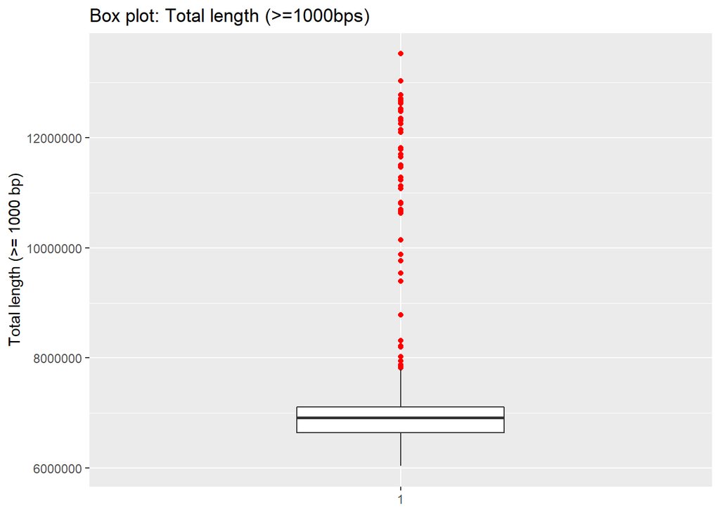

```r
library(ggplot2)
options(scipen=10000)
p <- ggplot(data, aes(x = factor(1), y = `Total length (>= 1000 bp)`)) +
  geom_boxplot(width = 0.4, fill = "white",outlier.colour = "red") + labs(x = NULL)  +ggtitle("Box plot: Total length (>=1000bps)")+theme_gray()
p
```

Question 5: Convert to 1 observation per row (Tidy format) with only sample) name, Metric and value.

```r
#Only for numeric variables
col.nums<-unlist(sapply(data[1,],is.numeric))
d3<-pivot_longer(data,which(col.nums==TRUE),names_to = "metric",values_to = "value")
final_data<-d3[,c("sample_name","metric","value")]
head(final_data)
```

```
## # A tibble: 6 x 3
##   sample_name metric                         value
##   <chr>       <chr>                          <dbl>
## 1 G18000072   contamination_percent           29.9
## 2 G18000072   # contigs (>= 1000 bp)         309
## 3 G18000072   N50                         119306
## 4 G18000072   Total length (>= 1000 bp) 12143060
## 5 G18000894   contamination_percent           14.2
## 6 G18000894   # contigs (>= 1000 bp)         737
```

```r
#For all metrics
d4<-sapply(data, as.character)
d4<-as.data.frame(d4)

d5<-pivot_longer(d4,2:12,names_to = "metric",values_to = "value")
final_data1<-d5[,c("sample_name","metric","value")]
head(final_data1)
```

```
## # A tibble: 6 x 3
##   sample_name metric                                         value
##   <chr>       <chr>                                          <chr>
## 1 G18000072   result                                         FAILURE
## 2 G18000072   confindr.contam_status.metric_value            TRUE
## 3 G18000072   confindr.contam_status.check_result            FAILURE
## 4 G18000072   contamination_percent                          29.87
## 5 G18000072   confindr.percentage_contamination.check_result FAILURE
## 6 G18000072   # contigs (>= 1000 bp)                         309
```

Question 6: Violin plots for all numeric variables  
Violin plots are similar to box plots, except that they also show the kernel probability density of the data at different values

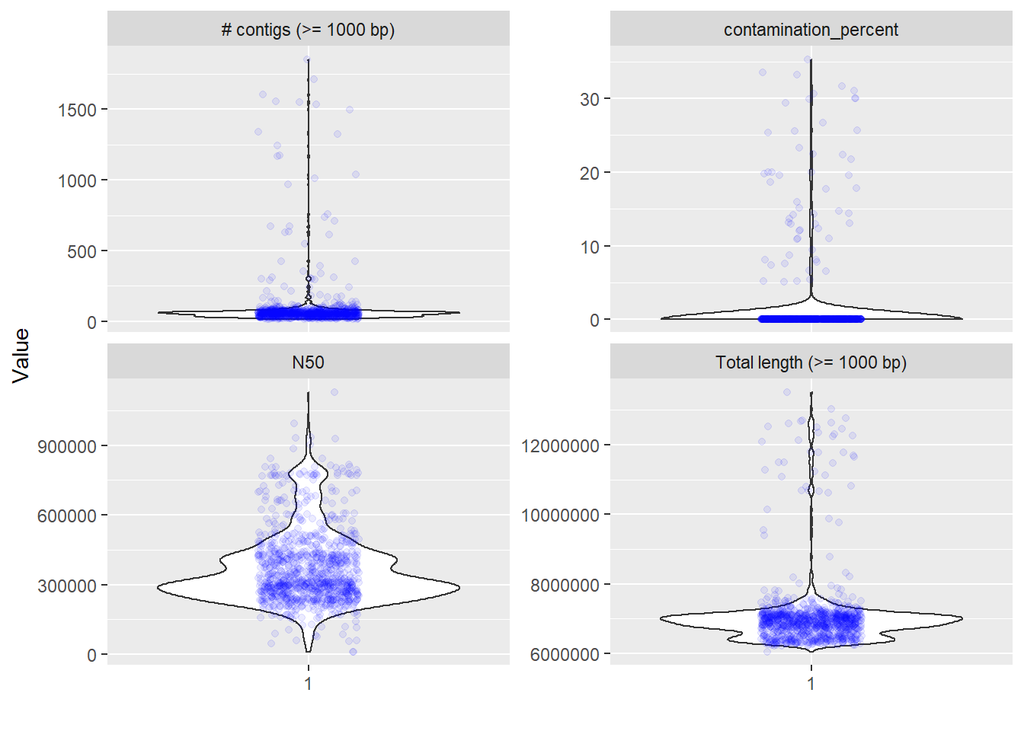

```r
# Basic violin
final_data$metric<-as.factor(final_data$metric)
p <- ggplot(final_data, aes(x=factor(1), y=as.numeric(value)),fill='white') +
  geom_violin()+ facet_wrap(~metric,  scales = "free_y")+ylab("Value")+xlab("") +geom_jitter(width=0.15, alpha=0.08,color='blue')+theme_gray()

p
```